# IODS: Final Assignment

Mirva Turkia

mirva.turkia@helsinki.fi

8.3.2017

# Abstract

*School is the place were adolescent spend great part of their week. I wanted to see whether lower support provided by teachers and parents, lower felt justice and lower feel of ones own worth and appreciation is connected to daily or weekly mental problems including tension and nervousness, irritability or outbursts of anger, problems with falling asleep or waking up at night time, tiredness or weakness, depression and fear.*

*I used Anne Konu´s survey data which is part of the School Well-being Profile -project. I chose 21 independent variables (gender + 20 Likert-scale questions) and 6 dependent variables (symptoms and illnesses). I used logistic regression to find the best model for each dependent variable.*

*Only gender had a clear impact on the models created. Other questions had mostly only minor impact on the models. The most important questions were whether or not parent´s help adolescent with they homework, adolescent feel that they have meaning in school and feeling oneself appreciated but also their impact on the models were quite small. The predictive power of the models was also very low when trying to find adolescents who have mental symptoms daily or weekly.*

# Research question

My aim is to explore if there is a connection between how well adolescents at grades 7-9 in lower secondary school get support from their teachers and families and how often they have mental symptoms. My hypothesis is that adolescents who get less support from their teachers and families, who don´t feel appreciated, who find their school´s rules unfair and unreasonable have more often (daily or weekly) mental symptoms which in this data are tension or nervousness, irritability or outbursts of anger, problems with falling asleep or waking up at night time, tiredness or weakness, depression or fear.

# The data

The survey data I will use is part of Anne Konu´s (University of Tampere) School Well-being Profile -project which is collected in years 2015-2016. The sample is not random because schools have took part to the project by their own accord if they have wanted to investigate their well-being profile. More information about the project you can find [here](http://www10.edu.fi/hyvinvointiprofiili/info.php?lang=) (only in Finnish or Swedish) and [here](https://services.fsd.uta.fi/catalogue/FSD3117?lang=en&study_language=en). The data is provided by The Finnish Social Science Data Archive.

Originally this data had 91 variables and 9820 observations. For this analysis I chose the following questions:

- g1: Gender
- q6_7: The rules of the school are reasonable.
- q6_8 The punishments of the school are fair.
- q7_9 The teachers treat us with justice.
- q7_10 It is easy to get along with the teachers.
- q7_11 Most of the teachers are interested in how I feel.
- q7_12 Most of the teachers are friendly.
- q10_1 My parents appreciate my schoolwork.
- q10_2 My parents encourage me to do well at school.
- q10_3 My parents help me with my homework if necessary.
- q10_4 My parents help me with problems related to school if necessary.
- q10_5 My parents are willing to come to the school to talk with a teacher if necessary.
- q11_1 My work is appreciated at school.
- q11_2 At school I´m regarded as a person who has a meaning.
- q11_3 The teachers encourage me to tell my opinion.
- q11_15 A teacher helps me if I need it.
- q11_16 I receive remediation if I need it.
- q11_17 I receive special education if I need it.
- q11_18 I receive quidance if I need it.
- q11_19 The teachers encourage me with studying.
- q11_20 I reserve acknowledgement if I do well with my tasks.

Have you had some of the following symptoms or illnesses during this semester? How often?

- q13_4 Tension or nervousness?
- q13_5 Irritability or outbursts of anger?
- q13_6 Problems with falling asleep or waking up at night time?
- q13_8 Tiredness or weakness?
- q13_9 Depression?
- q13_10 Fear?

After selecting these questions to the data I removed all the observations with missing values.

Questions from q6_7 to q11_20 are Likert scale questions with the following options:

- 1 = Strongly disagree
- 2 = Disagree
- 3 = Neither agree nor disagree
- 4 = Agree
- 5 = Strongly agree

In the original data these questions were categorical but I chose to change them to numeric to make their analysis easier.

Questions from q13_4 to q13_10 were also categorical and their options where the following:

- 0 = daily
- 1 = weekly
- 2 = monthly
- 3 = rarely
- 4 = none

At first I changed the options to start from number 1 (daily) and to end to number 5 (none). Then I changed them to numeric. After that I created new binomial variables of them where the options daily and weekly get value “true” and the others get value “false”.

You can find my data wrangling script [here](https://github.com/miuva/IODS-final/blob/master/Data/final_data_wrangling.R).

After all these changes there are now 34 variables and 8928 observations in this data.

```r
getwd()
```

```
## [1] "/Users/mirva/IODS-final"
```

```r
setwd("/Users/mirva/IODS-Final/Data")
school <- read.csv("school")
str(school)
```

```
## 'data.frame':    8928 obs. of  34 variables:
##  $ X          : int  1 2 3 4 5 6 7 8 9 10 ...
##  $ q1         : Factor w/ 2 levels "F","M": 1 1 2 1 1 2 2 1 2 1 ...
##  $ q6_7       : int  3 4 4 4 3 4 4 3 4 1 ...
##  $ q6_8       : int  4 3 4 4 3 3 2 3 4 1 ...
##  $ q7_9       : int  5 1 4 4 3 3 4 2 4 2 ...
##  $ q7_10      : int  5 2 4 4 3 4 5 2 4 3 ...
##  $ q7_11      : int  2 1 4 4 3 4 4 3 3 3 ...
##  $ q7_12      : int  3 3 4 4 3 3 4 2 3 2 ...
##  $ q10_1      : int  5 4 5 5 5 5 5 4 4 4 ...
##  $ q10_2      : int  5 4 5 5 5 5 4 5 4 4 ...
##  $ q10_3      : int  5 4 5 5 5 3 4 5 4 3 ...
##  $ q10_4      : int  5 4 5 5 5 4 4 5 4 4 ...
##  $ q10_5      : int  4 3 5 5 5 3 4 4 3 2 ...
##  $ q11_1      : int  4 4 4 4 3 4 3 3 3 4 ...
```

[output cut: 20 more lines]

```r
library(dplyr); library(ggplot2); library(boot)
```

# Visualizing the data

## Likert-scale questions

I will at first print the barplots for Likert-scale questions to see how the distributions of different questions look like.

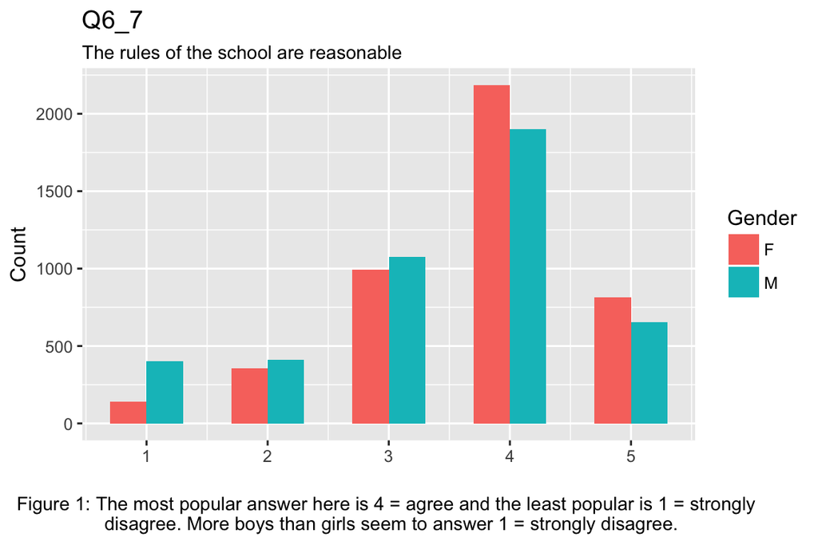

```r
g1 <- ggplot(data = school, aes(x = q6_7, fill = q1))
g1 + geom_bar(width = .6, position = "dodge") + labs(x = "", y = "Count", title ="Q6_7", subtitle = "The rules of the school are reasonable", caption = "Figure 1: The most popular answer here is 4 = agree and the least popular is 1 = strongly \n disagree. More boys than girls seem to answer 1 = strongly disagree.", fill = "Gender") + theme(plot.caption = element_text(hjust = 0.5))
```

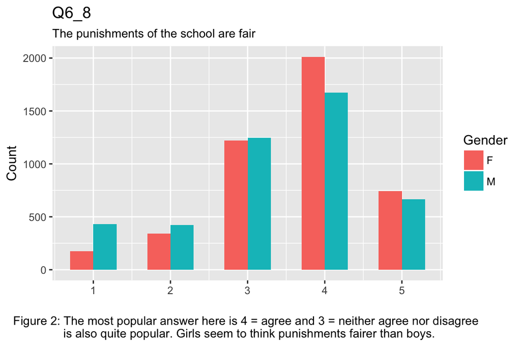

```r
g2 <- ggplot(data = school, aes(x = q6_8, fill = q1))
g2 + geom_bar(width = .6, position = "dodge") + labs(x = "", y = "Count", title ="Q6_8", subtitle = "The punishments of the school are fair", caption = "Figure 2: The most popular answer here is 4 = agree and 3 = neither agree nor disagree \n is also quite popular. Girls seem to think punishments fairer than boys.", fill = "Gender") + theme(plot.caption = element_text(hjust = 0.5))
```

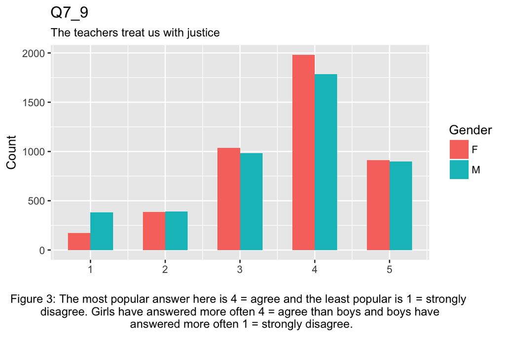

```r
g3 <- ggplot(data = school, aes(x = q7_9, fill = q1))
g3 + geom_bar(width = .6, position = "dodge") + labs(x = "", y = "Count", title ="Q7_9", subtitle = "The teachers treat us with justice", caption = "Figure 3: The most popular answer here is 4 = agree and the least popular is 1 = strongly \n disagree. Girls have answered more often 4 = agree than boys and boys have \n answered more often 1 = strongly disagree.", fill = "Gender") + theme(plot.caption = element_text(hjust = 0.5))
```

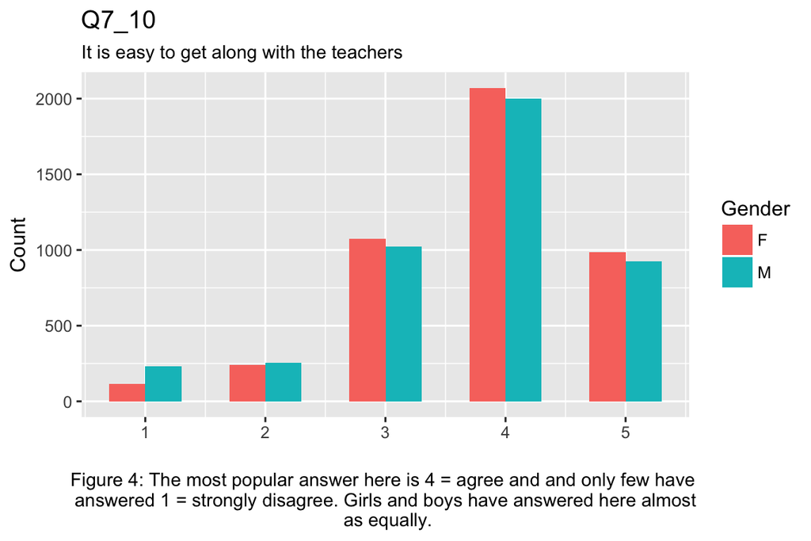

```r
g4 <- ggplot(data = school, aes(x = q7_10, fill = q1))
g4 + geom_bar(width = .6, position = "dodge") + labs(x = "", y = "Count", title ="Q7_10", subtitle = "It is easy to get along with the teachers", caption = "Figure 4: The most popular answer here is 4 = agree and and only few have \n answered 1 = strongly disagree. Girls and boys have answered here almost \n as equally.", fill = "Gender") + theme(plot.caption = element_text(hjust = 0.5))
```

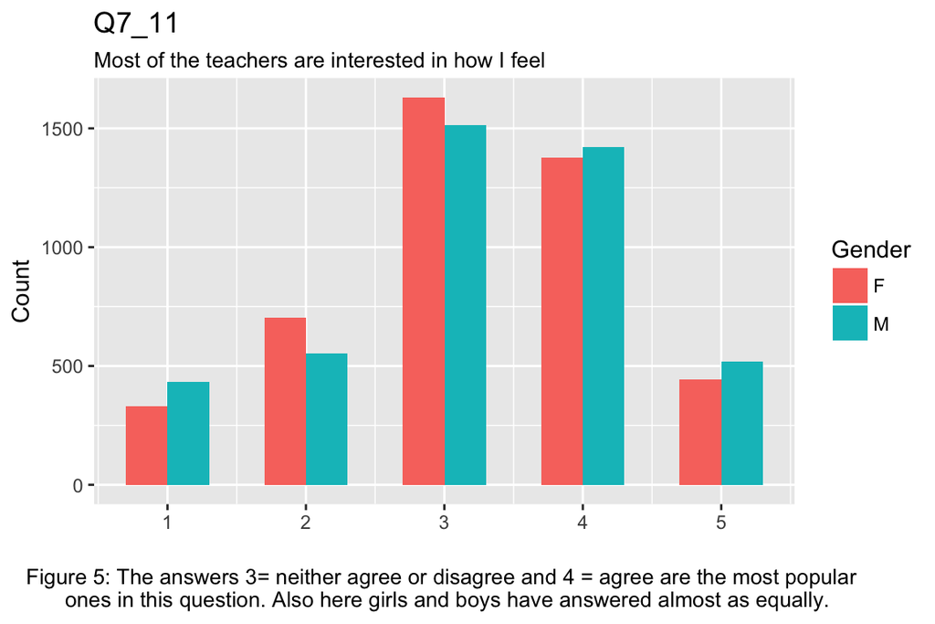

```r
g5 <- ggplot(data = school, aes(x = q7_11, fill = q1))
g5 + geom_bar(width = .6, position = "dodge") + labs(x = "", y = "Count", title ="Q7_11", subtitle = "Most of the teachers are interested in how I feel",  caption = "Figure 5: The answers 3= neither agree or disagree and 4 = agree are the most popular \n ones in this question. Also here girls and boys have answered almost as equally.", fill = "Gender") + theme(plot.caption = element_text(hjust = 0.5))
```

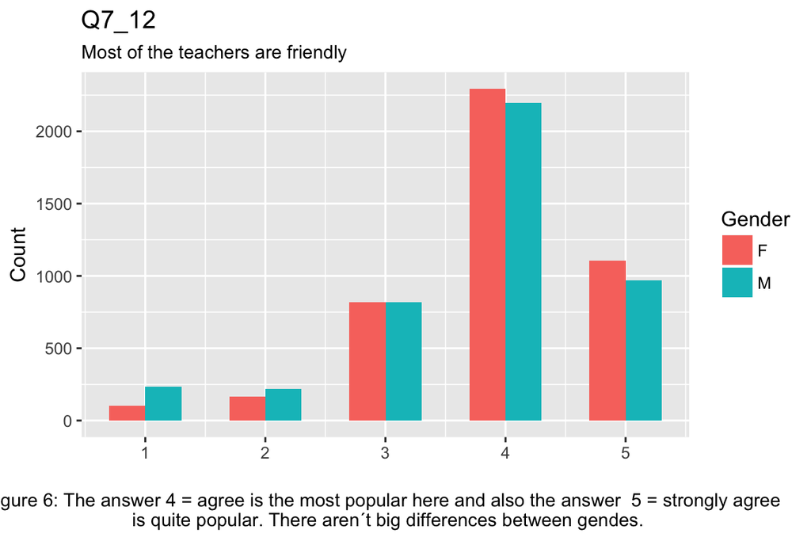

```r
g6 <- ggplot(data = school, aes(x = q7_12, fill = q1))
g6 + geom_bar(width = .6, position = "dodge") + labs(x = "", y = "Count", title ="Q7_12", subtitle = "Most of the teachers are friendly", caption = "Figure 6: The answer 4 = agree is the most popular here and also the answer  5 = strongly agree \n is quite popular. There aren´t big differences between gendes.", fill = "Gender") + theme(plot.caption = element_text(hjust = 0.5))
```

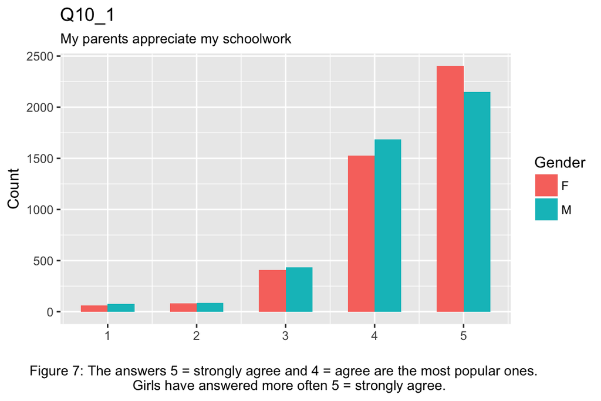

```r
g7 <- ggplot(data = school, aes(x = q10_1, fill = q1))
g7 + geom_bar(width = .6, position = "dodge") + labs(x = "", y = "Count", title ="Q10_1", subtitle = "My parents appreciate my schoolwork",  caption = "Figure 7: The answers 5 = strongly agree and 4 = agree are the most popular ones. \n  Girls have answered more often 5 = strongly agree.", fill = "Gender") + theme(plot.caption = element_text(hjust = 0.5))
```

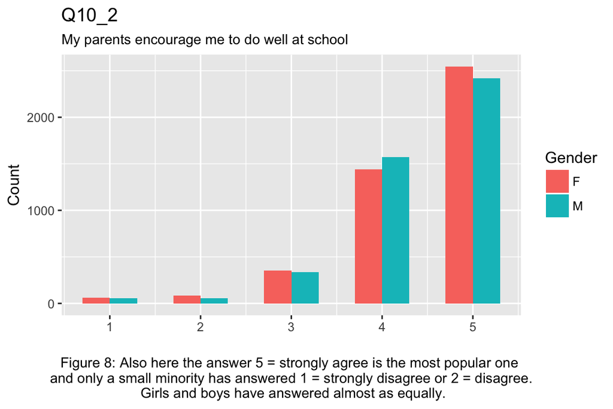

```r
g8 <- ggplot(data = school, aes(x = q10_2, fill = q1))
g8 + geom_bar(width = .6, position = "dodge") + labs(x = "", y = "Count", title ="Q10_2", subtitle = "My parents encourage me to do well at school",  caption = "Figure 8: Also here the answer 5 = strongly agree is the most popular one \n and only a small minority has answered 1 = strongly disagree or 2 = disagree. \n Girls and boys have answered almost as equally.", fill = "Gender") + theme(plot.caption = element_text(hjust = 0.5))
```

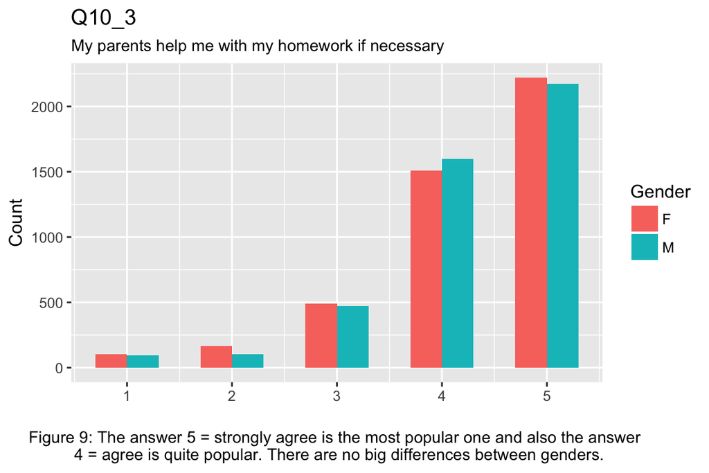

```r
g9 <- ggplot(data = school, aes(x = q10_3, fill = q1))
g9 + geom_bar(width = .6, position = "dodge") + labs(x = "", y = "Count", title ="Q10_3", subtitle = "My parents help me with my homework if necessary",  caption = "Figure 9: The answer 5 = strongly agree is the most popular one and also the answer \n 4 = agree is quite popular. There are no big differences between genders.", fill = "Gender") + theme(plot.caption = element_text(hjust = 0.5))
```

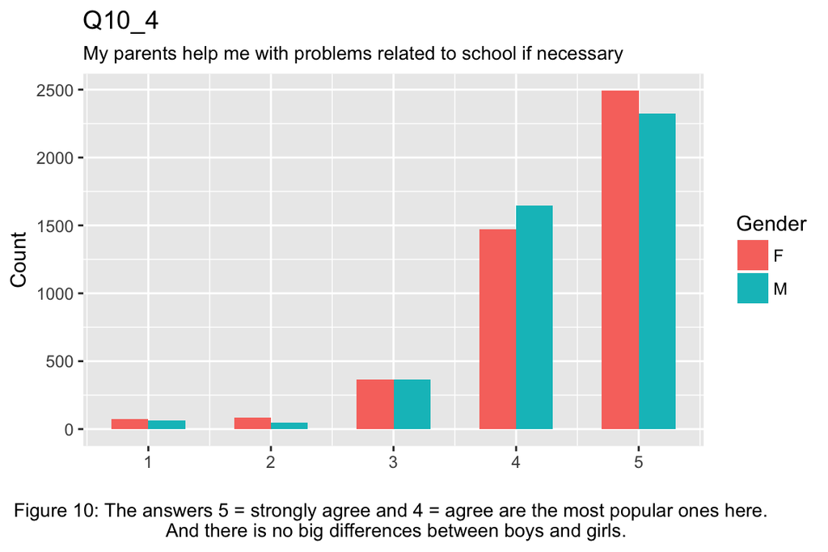

```r
g10 <- ggplot(data = school, aes(x = q10_4, fill = q1))
g10 + geom_bar(width = .6, position = "dodge") + labs(x = "", y = "Count", title ="Q10_4", subtitle = "My parents help me with problems related to school if necessary",  caption = "Figure 10: The answers 5 = strongly agree and 4 = agree are the most popular ones here. \n And there is no big differences between boys and girls.", fill = "Gender") + theme(plot.caption = element_text(hjust = 0.5))
```